# Moodle Tasks

б) exac.pay от пакета UsingR;

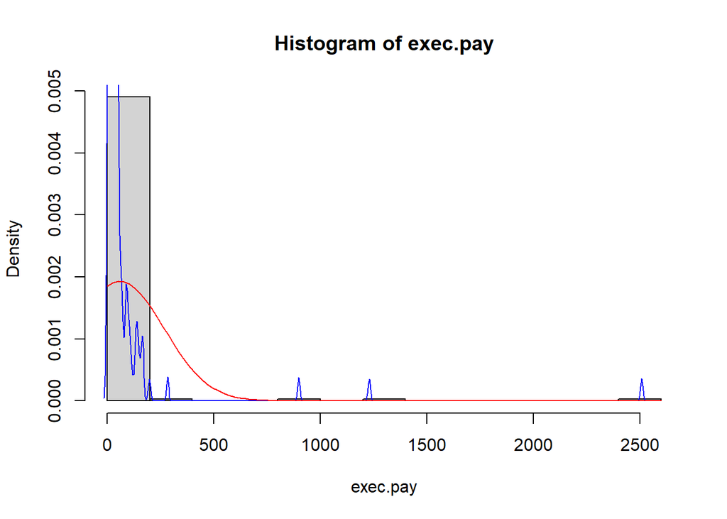

```r
> hist(exec.pay, probability = TRUE)
> lines(density(exec.pay, bw = "SJ"), col = "blue")
> x = exec.pay
> curve(dnorm(x, mean(exec.pay), sd(exec.pay)), add = TRUE, col = "red")
```

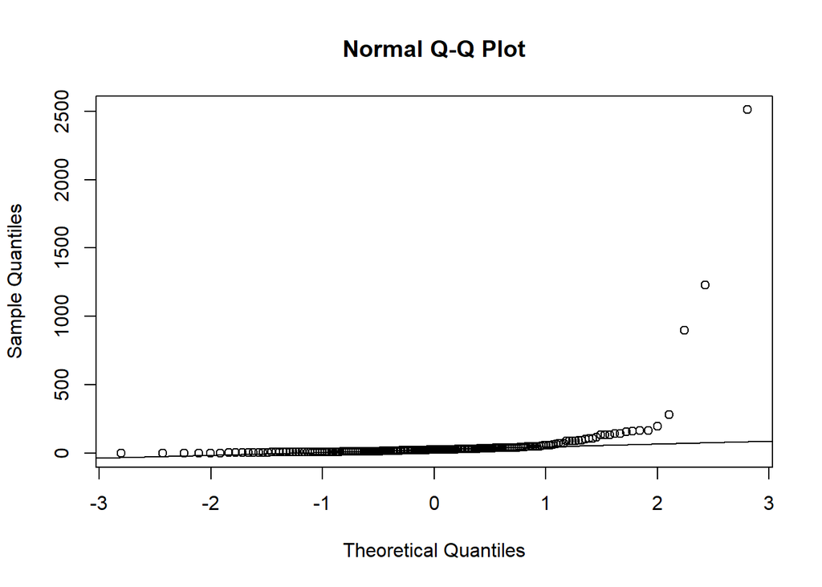

```r
> qqnorm(exec.pay)
> qqline(exec.pay)
```

```r
> shapiro.test(exec.pay)

    Shapiro-Wilk normality test

data:  exec.pay
W = 0.19352, p-value < 2.2e-16
```

Имаме $p-value < 2.2e-16 < 0.05 = \alpha$, което означава, че разпределението ни е значително по-различно от нормалното разпределение, т.е. нямаме основание да допуснем, че данните ни са нормално разпределени.

## Задача 4

Размерът на пъпешите е нормално разпределена сл.в. с очакване 25см. и дисперсия 36. Пъпешите по-малки от 20см. са трето качество, а останалите се разделят на две равни по брой групи, като по-големите са първо качество, а по-малките второ. Каква част от пъпешите са трето качество. Колко голям трябва да е пъпеша за да бъде първо качество.

### Решение:

$$X \in N(25, 6^2)$$
$$(X < 20) - \text{ 3-то качество}$$
$$\frac{\#(X \geq 20)}{2} = \#(\text{1-во качество}) = \#(\text{2-ро качество})$$

```r
> pnorm(q = 20, mean = 25, sd = 6)
[1] 0.2023284
```

$$P(X < 20) = 0.2023284$$
т.е. 20.23% от пъпешите са 3-то качество.

```r
> qnorm(p = 0.2023284 + (1 - 0.2023284)/2, mean = 25, sd = 6)
[1] 26.53817
```

$$q = F_X^{\leftarrow}{( 0.2023284 + \frac{1 - 0.2023284}{2})} = 26.53817$$
т.е. за да бъде 1-во качество пъпешът трябва да бъде над 26.54см.

## Задача 5

Нека сл.в. $X$ е гамма разпределена с параметри 2 и 0.5. Определете:

1. $P(X < 1)$;

```r
> pgamma(1, shape = 2, rate = 0.5)
[1] 0.09020401
```

б) $P(X > 2)$;

```r
> pgamma(2, shape = 2, rate = 0.5, lower.tail = FALSE)
[1] 0.7357589
```

в) $c$, така че $P(X > c) = 0.35$;

```r
> qgamma(0.35, shape = 2, rate = 0.5, lower.tail = FALSE)
[1] 4.437689
```

г) $Q_1$, $M$, $Q_3$

```r
> qgamma(0.25, shape = 2, rate = 0.5)
[1] 1.922558
> qgamma(0.5, shape = 2, rate = 0.5)
[1] 3.356694
> qgamma(0.75, shape = 2, rate = 0.5)
[1] 5.385269
```